# DS7337_Class401_HW08_SGu

### SMU NLP Course (DS7337) -- Homework 08 submission (08-12-2019)

### Perform a vocabulary-based sentiment analysis of the movie reviews

### Shanqing Gu (Class 401)

### Table of Contents:

#### Q1. Sentiment Analysis with TextBlob and AFINN Lexicons for Individual Movie Review

- Q1.1 - Sentiment Analysis with TextBlob Lexicon for Individual Movie Review
  - Q1.1.1 - Load IMDB Review Dataset from Homework 7 with 4 KMeans Clusters (km4_pws)
  - Q1.1.2 - Sentiment Analysis with TextBlob Lexicon for Individual Movie Review
  - Q1.1.3 - Sentiment Analysis with the Entire Movie Reviews
- Q1.2 - Sentiment Analysis with AFINN Lexicon for Individual Movie Review
  - Q1.2.1 - Sentiment Analysis with AFINN Lexicon for Individual Movie Review
  - Q1.2.2 - Sentiment Analysis with the Entire Movie Reviews

#### Q2. Sentiment Analysis with TextBlob Lexicons for HW7 Movie Review Clusters

- Q2.1 - Functions for Corpus Normalization
- Q2.2 - Polarity and Subjectivity for All the Individual Movie Reviews
- Q2.3 - Polarity and Subjectivity with KMeans Clusters (km4_pws)
- Q2.4 - Polarity and Subjectivity with Two Scales (scale =0 or 1)
- Q2.5 - Summary

#### Q3. Sentiment Analysis with Movie Review Chunks

- Q3.1 - Run Each Chunk Individually through TextBlob Lexicon
- Q3.2 - Highest Negative-Sentiment-Scoring Chunks
- Q3.3 - Highest Positive-Sentiment-Scoring Chunks
- Q3.4 - Summary

```python
## Import libraries needed for homework 08

import pandas as pd
import numpy as np
import pickle
import re
import string
import collections
import seaborn as sns
import html

import nltk
from nltk import word_tokenize
from nltk.stem import WordNetLemmatizer

from contractions import CONTRACTION_MAP
from sklearn import metrics as mt
from textblob import TextBlob
from afinn import Afinn

import matplotlib.pyplot as plt
%matplotlib inline
```

#### Q1: Sentiment Analysis with TextBlob and AFINN Lexicons for Individual Movie Reviews

In Python, load one of the sentiment vocabularies referenced in the textbook, and run the sentiment analyzer as explained in the corresponding reference. Add words to the sentiment vocabulary, if you think you need to, to better fit your particular text collection.

Back to top

#### Q1.1: Sentiment Analysis with TextBlob Lexicon for Individual Movie Review

TextBlob lexicon is one of the popular lexicon models used for sentiment analysis. TextBlob supports Python >=2.7 or >=3.4. The lexicon that TextBlob uses is the same one as pattern package which is only available for Python 2.7.x versions.

Back to top

#### Q1.1.1 Load IMDB Review Dataset from Homework 7 with 4 KMeans Clusters (km4_pws)

Use the preprocessed movie reviews from homework 07 with 4 KMeans clusters (km4_pws). There are 956 movie reviews with 4 clusters.

```python
## Movie review data was from HW-05
with open('MoviesReviews_km4_pws.p', 'rb') as f:
    MoviesReviews = pickle.load(f)
```

```python
## Check data movie review data with head()
MoviesReviews.head(5)
```

|  | Movie | rRating | rTitle | rReview | rAuthor | rDate | rLink | Scale | Chunks | Tokens | km4_pws |
| --- | --- | --- | --- | --- | --- | --- | --- | --- | --- | --- | --- |
| 0 | A Quiet Place | 10/10 | For all the bashers of this movie | 1) The actress who is deaf in the movie is dea... | shaneandamy-196294 | August/2018 | http://www.imdb.com/review/rw4267600/?ref_=tt_... | 1 | [the actress, is, deaf, in, the movie, is, dea... | [actress, deaf, movie, deaf, real, life, alien... | 2 |
| 1 | A Quiet Place | 10/10 | Love it! | I am Deaf. I realllllly enjoy it!! So it good ... | zechpetersen7 | April/2018 | http://www.imdb.com/review/rw4119874/?ref_=tt_... | 1 | [i, am, deaf, i, realllllly enjoy, it, so, it,... | [deaf, realllllly, enjoy, good, people, know, ... | 2 |
| 2 | A Quiet Place | 8/10 | Nicely done horror + thriller, quite recommen... | "A Quiet Place" directed by John Krasinski is ... | NpMoviez17 | July/2018 | http://www.imdb.com/review/rw4242428/?ref_=tt_... | 1 | [a quiet place, directed, by, john krasinski, ... | [quiet, place, direct, john, krasinski, genuin... | 0 |
| 3 | A Quiet Place | 8/10 | A Quiet Place: As good as they say | A Quiet Place was critically acclaimed and for... | Platypuschow12 | November/2018 | http://www.imdb.com/review/rw4453015/?ref_=tt_... | 1 | [a quiet place, was critically acclaimed, for,... | [quiet, place, critically, acclaim, reason, te... | 0 |
| 4 | A Quiet Place | 8/10 | Tense! | A Quiet Place starts with racking up the tensi... | lynseylinzlu2 | April/2018 | http://www.imdb.com/review/rw4114242/?ref_=tt_... | 1 | [a quiet place, starts, with, racking, up, the... | [quiet, place, start, rack, tension, let, nerv... | 3 |

```python
## check data shape of movie reviews: 956
MoviesReviews.shape
```

```
(956, 11)
```

```python
## count variable "Scale": "1" for 423 and "0" for 533 instances
collections.Counter(MoviesReviews.Scale)
```

```
Counter({1: 423, 0: 533})
```

```python
## change Scale=1 to "Positive" and scle=0 to "Negative",
## "Positive" for rRating ('10/10','9/10', '8/10', '7/10') and others as "Negative"
p_sm=MoviesReviews[MoviesReviews['Scale']==1].copy()
p_sm['SM']='Positive'

n_sm=MoviesReviews[MoviesReviews['Scale']==0].copy()
n_sm['SM']='Negative'

MoviesReviews_sm=pd.concat([p_sm, n_sm],axis=0)
```

```python
## reviews and sentiments for model evaluation
reviews = np.array(MoviesReviews_sm['rReview'])
sentiments = np.array(MoviesReviews_sm['SM'])
```

```python
## sample movie review IDs
sample_review_ids = [100, 400, 800]
```

#### Q1.1.2 Sentiment Analysis with TextBlob Lexicon for Individual Movie Review

```python
## The sentiment property from TextBlob returns a named tuple of the form Sentiment(polarity, subjectivity)
## Typically, specific adjectives have a polarity score is a float within the range [-1.0, 1.0]
## and a sujective score is a float within the range [0.0, 1.0] where 0.0 is very objective and 1.0 is very subjective

for review, sentiment in zip(reviews[sample_review_ids], sentiments[sample_review_ids]):
    print('REVIEW:', review)
    print('Actual Sentiment:', sentiment)
    print('Predicted Sentiment Polarity:', TextBlob(review).sentiment.polarity)
    print('Predicted Sentiment Subjectivity:', TextBlob(review).sentiment.subjectivity)
    print('-'*60)
```

```
REVIEW: I just saw the world premiere and oh boy let me tell you about it:This movie might not be a masterpiece but my heart is filled with such happiness and joy after watching it that I think it's going to burst (sorry for the cheesiness), Freddie Mercury, Brian May, Roger Taylor and John Deacon a…
Actual Sentiment: Positive
Predicted Sentiment Polarity: 0.29707070707070715
Predicted Sentiment Subjectivity: 0.6383333333333333
------------------------------------------------------------
REVIEW: What an unexpectedly brilliant movie. Lots of laughs, some moments that I almost couldn't look, fabulously different story line, last minute surprise ending, car chases, and brilliant fight scenes.
Actual Sentiment: Positive
Predicted Sentiment Polarity: 0.45
Predicted Sentiment Subjectivity: 0.6666666666666667
------------------------------------------------------------
REVIEW: Based upon the book of the same name by ex-CIA agent Jason Matthews, Red Sparrow is a modern-day spy thriller by director Francis Lawrence (Hunger Games: Catching Fire, I Am Legend) that harks back to the days of the cold war thrillers of the 70s/80s but fails to update it appropriately, com…
Actual Sentiment: Negative
Predicted Sentiment Polarity: -0.012839446589446597
Predicted Sentiment Subjectivity: 0.5804268554268552
------------------------------------------------------------
```

#### Q1.1.3 Sentiment Analysis with the Entire Movie Reviews

```python
## get_metrics function to calculate accuracy, precision, recall abd F1 score
def get_metrics(true_labels, predicted_labels):
    print('Accuracy:', np.round(mt.accuracy_score(true_labels, predicted_labels),4))
    print('Precision:', np.round(mt.precision_score(true_labels, predicted_labels, average='weighted'), 4))
    print('Recall:', np.round(mt.recall_score(true_labels, predicted_labels, average='weighted'), 4))
    print('F1 Score:', np.round(mt.f1_score(true_labels, predicted_labels, average='weighted'), 4))
```

```python
## function display_confusion_matrix to display confusion matrix
def display_confusion_matrix(true_labels, predicted_labels, classes=[1,0]):
    total_classes = len(classes)
    level_labels = [total_classes*[0], list(range(total_classes))]
    cm = mt.confusion_matrix(y_true=true_labels, y_pred=predicted_labels, labels=classes)
    cm_frame = pd.DataFrame(data=cm,
                            columns=pd.MultiIndex(levels=[['Predicted:'], classes], codes=level_labels),
                            index=pd.MultiIndex(levels=[['Actual:'], classes], codes=level_labels))
    print(cm_frame)
```

```python
## function display_classification_report
def display_classification_report(true_labels, predicted_labels, classes=[1,0]):
    report = mt.classification_report(y_true=true_labels, y_pred=predicted_labels, labels=classes)
    print(report)
```

```python
## function display_model_performance_metrics for model metrices and report
def display_model_performance_metrics(true_labels, predicted_labels, classes=[1,0]):
    print('Model Performance metrics:')
    print('-'*30)
    get_metrics(true_labels=true_labels, predicted_labels=predicted_labels)
    print('\nModel Classification report:')
    print('-'*30)
    display_classification_report(true_labels=true_labels, predicted_labels=predicted_labels, classes=classes)
    print('\nPrediction Confusion Matrix:')
    print('-'*30)
    display_confusion_matrix(true_labels=true_labels, predicted_labels=predicted_labels, classes=classes)
```

```python
## use a custome threshhold 0.1 to compute the entire movie reviews
sentiment_polarity = [TextBlob(review).sentiment.polarity for review in reviews]
predicted_sentiments = ['Positive' if score>=0.1 else 'Negative' for score in sentiment_polarity]
```

```python
## get model performance metrics and report
display_model_performance_metrics(true_labels=sentiments,
                                  predicted_labels=predicted_sentiments,
                                  classes = ['Positive', 'Negative'])
```

```
Model Performance metrics:
------------------------------
Accuracy: 0.7385
Precision: 0.7537
Recall: 0.7385
F1 Score: 0.7389

Model Classification report:
------------------------------
              precision    recall  f1-score   support

    Positive       0.67      0.82      0.73       423
    Negative       0.82      0.68      0.74       533

    accuracy                           0.74       956
   macro avg       0.74      0.75      0.74       956
weighted avg       0.75      0.74      0.74       956


Prediction Confusion Matrix:
------------------------------
                 Predicted:
                   Positive Negative
Actual: Positive        345       78
        Negative        172      361
```

#### Q1.2: Sentiment Analysis with AFINN Lexicon for Individual Movie Review

The AFINN lexicon is one of the simplest and most popular lexicons and can be used extensively for sentiment analysis. We can compute the polarity of movie reviews and get the model performance.

Back to top

#### Q1.2.1 Sentiment Analysis with AFINN Lexicon for Individual Movie Review

```python
## use AFINN lexicon
afn = Afinn(emoticons=True)
```

```python
## The sentiment property from AFINN lexicon returns a named tuple of the form Sentiment score
for review, sentiment in zip(reviews[sample_review_ids], sentiments[sample_review_ids]):
    print('REVIEW:', review)
    print('Actual Sentiment:', sentiment)
    print('Predicted Sentiment Polarity:', afn.score(review))
    print('-'*60)
```

```
REVIEW: I just saw the world premiere and oh boy let me tell you about it:This movie might not be a masterpiece but my heart is filled with such happiness and joy after watching it that I think it's going to burst (sorry for the cheesiness), Freddie Mercury, Brian May, Roger Taylor and John Deacon a…
Actual Sentiment: Positive
Predicted Sentiment Polarity: 15.0
------------------------------------------------------------
REVIEW: What an unexpectedly brilliant movie. Lots of laughs, some moments that I almost couldn't look, fabulously different story line, last minute surprise ending, car chases, and brilliant fight scenes.
Actual Sentiment: Positive
Predicted Sentiment Polarity: 12.0
------------------------------------------------------------
REVIEW: Based upon the book of the same name by ex-CIA agent Jason Matthews, Red Sparrow is a modern-day spy thriller by director Francis Lawrence (Hunger Games: Catching Fire, I Am Legend) that harks back to the days of the cold war thrillers of the 70s/80s but fails to update it appropriately, com…
Actual Sentiment: Negative
Predicted Sentiment Polarity: -20.0
------------------------------------------------------------
```

#### Q1.2.2 Sentiment Analysis with the Entire Movie Reviews

```python
## use a custome threshhold 5 to compute the entire movie reviews
sentiment_polarity = [afn.score(review) for review in reviews]
predicted_sentiments = ['Positive' if score>=5 else 'Negative' for score in sentiment_polarity]
```

```python
## get model performance metrics and report
display_model_performance_metrics(true_labels=sentiments,
                                  predicted_labels=predicted_sentiments,
                                  classes = ['Positive', 'Negative'])
```

```
Model Performance metrics:
------------------------------
Accuracy: 0.7259
Precision: 0.7472
Recall: 0.7259
F1 Score: 0.7257

Model Classification report:
------------------------------
              precision    recall  f1-score   support

    Positive       0.65      0.83      0.73       423
    Negative       0.82      0.65      0.72       533

    accuracy                           0.73       956
   macro avg       0.74      0.74      0.73       956
weighted avg       0.75      0.73      0.73       956


Prediction Confusion Matrix:
------------------------------
                 Predicted:
                   Positive Negative
Actual: Positive        350       73
        Negative        189      344
```

#### Q2: Sentiment Analysis with TextBlob Lexicon for HW7 Movie Review Clusters

For each of the clusters you created in homework 7, compute the average, median, high, and low sentiment scores for each cluster. Explain whether you think this reveals anything interesting about the clusters.

Back to top

#### Q2.1: Functions for Corpus Normalization

```python
## normalize_corpus function to normalize corpus
def normalize_corpus(corpus, lemmatize=True, only_text_chars=False, tokenize=False):

    normalized_corpus = []

    for text in corpus:
        text = html.unescape(text)
        text = expand_contractions(text, CONTRACTION_MAP)

        if lemmatize:
            text = lemmatize_text(text)
        else:
            text = text.lower()
        text = remove_special_characters(text)
        text = remove_stopwords(text)

        if only_text_chars:
            text = keep_text_characters(text)

        if tokenize:
            text = tokenize_text(text)
            normalized_corpus.append(text)
        else:
            normalized_corpus.append(text)

    return normalized_corpus
```

```python
## expand_contractions function to expand contractions
def expand_contractions(text, contraction_mapping):
    contractions_pattern = re.compile('({})'.format('|'.join(contraction_mapping.keys())),
                                      flags=re.IGNORECASE|re.DOTALL)
    def expand_match(contraction):
        match = contraction.group(0)
        first_char = match[0]
        expanded_contraction = contraction_mapping.get(match)\
                               if contraction_mapping.get(match)\
                               else contraction_mapping.get(match.lower())
        expanded_contraction = first_char+expanded_contraction[1:]
        return expanded_contraction

    expanded_text = contractions_pattern.sub(expand_match, text)
    expanded_text = re.sub("'", "", expanded_text)
    return expanded_text
```

```python
## remove_special_characters function to remove special characters
def remove_special_characters(text):
    tokens = tokenize_text(text)
    pattern = re.compile('[{}]'.format(re.escape(string.punctuation)))
    filtered_tokens = filter(None, [pattern.sub(' ', token) for token in tokens])
    filtered_text = ' '.join(filtered_tokens)
    return filtered_text
```

```python
## tokenize_text function for tokenization
def tokenize_text(text):
    tokens = nltk.word_tokenize(text)
    tokens = [token.strip() for token in tokens]
    return tokens
```

```python
## remove_stopwords function to remove stop words
def remove_stopwords(text):
    tokens = tokenize_text(text)
    stopword_list = nltk.corpus.stopwords.words('english')
    filtered_tokens = [token for token in tokens if token not in stopword_list]
    filtered_text = ' '.join(filtered_tokens)
    return filtered_text
```

#### Q2.2: Polarity and Subjectivity for All the Individual Movie Review

```python
## normalize rReview and save in variable "Corpus"
MoviesReviews["Corpus"] = normalize_corpus(MoviesReviews.rReview, lemmatize=False )
```

```python
## calculate polarity and subjectivity for individual movie review with TextBlob
MoviesReviews['Polarity'] = MoviesReviews['Corpus'].apply(lambda x: TextBlob(x).sentiment.polarity)
MoviesReviews['Subjectivity'] = MoviesReviews['Corpus'].apply(lambda x: TextBlob(x).sentiment.subjectivity)
MoviesReviews.head(2)
```

|  | Movie | rRating | rTitle | rReview | rAuthor | rDate | rLink | Scale | Chunks | Tokens | km4_pws | Corpus | Polarity | Subjectivity |
| --- | --- | --- | --- | --- | --- | --- | --- | --- | --- | --- | --- | --- | --- | --- |
| 0 | A Quiet Place | 10/10 | For all the bashers of this movie | 1) The actress who is deaf in the movie is dea... | shaneandamy-196294 | August/2018 | http://www.imdb.com/review/rw4267600/?ref_=tt_... | 1 | [the actress, is, deaf, in, the movie, is, dea... | [actress, deaf, movie, deaf, real, life, alien... | 2 | 1 actress deaf movie deaf real life 2 aliens b... | 0.084787 | 0.443537 |
| 1 | A Quiet Place | 10/10 | Love it! | I am Deaf. I realllllly enjoy it!! So it good ... | zechpetersen7 | April/2018 | http://www.imdb.com/review/rw4119874/?ref_=tt_... | 1 | [i, am, deaf, i, realllllly enjoy, it, so, it,... | [deaf, realllllly, enjoy, good, people, know, ... | 2 | deaf realllllly enjoy good people know sign la... | 0.400000 | 0.400000 |

#### Q2.3: Polarity and Subjectivity with KMeans Clusters (km4_pws)

```python
## compute the average, median, high, and low sentiment scores for each KMeans cluster
## reference: https://www.shanelynn.ie/summarising-aggregation-and-grouping-data-in-python-pandas/
MoviesReviews.groupby('km4_pws', as_index=True).agg({"Polarity":['count', 'min', 'mean', 'median', 'max']})
```

| km4_pws | Polarity count | Polarity min | Polarity mean | Polarity median | Polarity max |
| --- | --- | --- | --- | --- | --- |
| 0 | 265 | -0.270000 | 0.105426 | 0.103896 | 0.610 |
| 1 | 184 | -0.800000 | 0.064972 | 0.093983 | 1.000 |
| 2 | 287 | -0.433333 | 0.130953 | 0.123958 | 1.000 |
| 3 | 220 | -0.225000 | 0.142661 | 0.130975 | 0.675 |

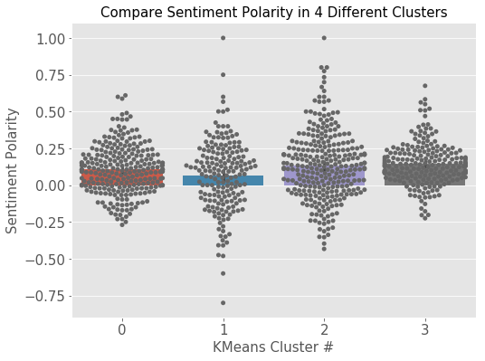

```python
## use barplot and swarmplot to compare the sentiment polarity in 4 different clusters
sns.set_palette("husl")
plt.style.use('ggplot')

plt.figure(figsize=(8,6))
b = sns.barplot(x = "km4_pws", y = "Polarity", data = MoviesReviews)
s= sns.swarmplot(x = "km4_pws", y = "Polarity", data = MoviesReviews, color=".4")

b.axes.set_title("Compare Sentiment Polarity in 4 Different Clusters",fontsize=15)
b.set_xlabel("KMeans Cluster #", fontsize=15)
b.set_ylabel("Sentiment Polarity",fontsize=15)
b.tick_params(labelsize=15)

plt.savefig('km4_pws_pol.png', dpi=300)
```

```python
## compute the average, median, high, and low subjectivity scores for each KMeans cluster
MoviesReviews.groupby('km4_pws', as_index=True).agg({"Subjectivity":['count', 'min', 'mean', 'median', 'max']})
```

| km4_pws | Subjectivity count | Subjectivity min | Subjectivity mean | Subjectivity median | Subjectivity max |
| --- | --- | --- | --- | --- | --- |
| 0 | 265 | 0.1 | 0.535342 | 0.533928 | 0.900000 |
| 1 | 184 | 0.0 | 0.533338 | 0.539502 | 1.000000 |
| 2 | 287 | 0.2 | 0.543609 | 0.550000 | 1.000000 |
| 3 | 220 | 0.3 | 0.532712 | 0.528110 | 0.803846 |

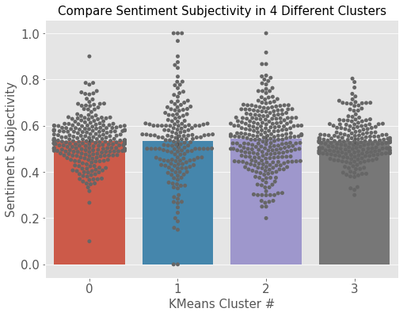

```python
## use barplot and swarmplot to compare the sentiment subjectivity in 4 different clusters
sns.set_palette("husl")
plt.style.use('ggplot')

plt.figure(figsize=(8,6))
b = sns.barplot(x = "km4_pws", y = "Subjectivity", data = MoviesReviews)
s= sns.swarmplot(x = "km4_pws", y = "Subjectivity", data = MoviesReviews, color=".4")

b.axes.set_title("Compare Sentiment Subjectivity in 4 Different Clusters",fontsize=15)
b.set_xlabel("KMeans Cluster #", fontsize=15)
b.set_ylabel("Sentiment Subjectivity",fontsize=15)
b.tick_params(labelsize=15)

plt.savefig('km4_pws_sub.png', dpi=300)
```

#### Q2.4: Polarity and Subjectivity with Two Scales (scale =0 or 1)

```python
## compute the average, median, high, and low sentiment scores for two classes (Scale= 0 or 1)
MoviesReviews.groupby('Scale', as_index=True).agg({"Polarity":['count', 'min', 'mean', 'median', 'max']})
```

| Scale | Polarity count | Polarity min | Polarity mean | Polarity median | Polarity max |
| --- | --- | --- | --- | --- | --- |
| 0 | 533 | -0.6 | 0.026022 | 0.027642 | 0.733333 |
| 1 | 423 | -0.8 | 0.224568 | 0.202868 | 1.000000 |

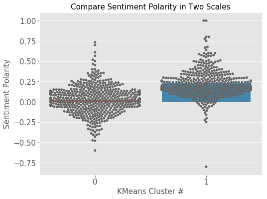

```python
## use barplot and swarmplot to compare the sentiment polarity for two classes (Scale= 0 or 1)
sns.set_palette("husl")
plt.style.use('ggplot')

plt.figure(figsize=(8,6))
b = sns.barplot(x = "Scale", y = "Polarity", data = MoviesReviews)
s= sns.swarmplot(x = "Scale", y = "Polarity", data = MoviesReviews, color=".4")

b.axes.set_title("Compare Sentiment Polarity in Two Scales",fontsize=15)
b.set_xlabel("KMeans Cluster #", fontsize=15)
b.set_ylabel("Sentiment Polarity",fontsize=15)
b.tick_params(labelsize=15)

plt.savefig('scale_pws_pol.png', dpi=300)
```

```python
## compute the average, median, high, and low subjectivity scores for two classes (Scale= 0 or 1)
MoviesReviews.groupby('Scale', as_index=True).agg({"Subjectivity":['count', 'min', 'mean', 'median', 'max']})
```

| Scale | Subjectivity count | Subjectivity min | Subjectivity mean | Subjectivity median | Subjectivity max |
| --- | --- | --- | --- | --- | --- |
| 0 | 533 | 0.000000 | 0.526388 | 0.527556 | 1.0 |
| 1 | 423 | 0.246667 | 0.549993 | 0.539474 | 1.0 |

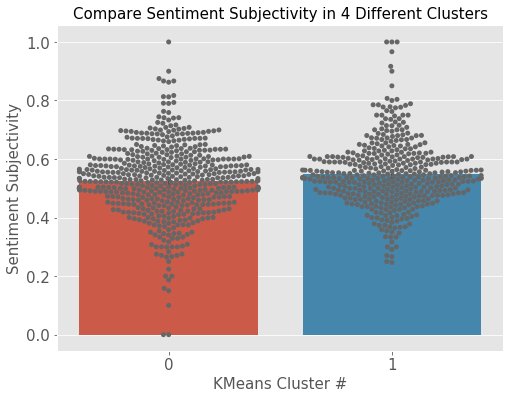

```python
## use barplot and swarmplot to compare the sentiment subjectivity for two classes (Scale= 0 or 1)
sns.set_palette("husl")
plt.style.use('ggplot')

plt.figure(figsize=(8,6))
b = sns.barplot(x = "Scale", y = "Subjectivity", data = MoviesReviews)
s= sns.swarmplot(x = "Scale", y = "Subjectivity", data = MoviesReviews, color=".4")

b.axes.set_title("Compare Sentiment Subjectivity in 4 Different Clusters",fontsize=15)
b.set_xlabel("KMeans Cluster #", fontsize=15)
b.set_ylabel("Sentiment Subjectivity",fontsize=15)
b.tick_params(labelsize=15)

plt.savefig('scale_pws_sub.png', dpi=300)
```

#### Q2.5: Summary

In sentiment analysis, polarity refers to the emotion expressed in the sentence (positive, neutral, and negative), and subjectivity refers to the opinions that describe personal views towards a specific subject or topic.

There are 4 KMeans clusters (0,1,2,3) from HW-07. The sample distributions are similar (265, 184, 287, 220), and values for sentiment subjectivity are very close (0.534, 0.540, 0.550, 0.528). However, the sentiment polarity values are varied. For example, cluster 0 has higher polarity value (mean=0.105) than cluster 1 (mean=0.065), but lower than clusters 2 and 3 (mean = 0.131 and 0.143 separately). These results suggest clusters 2 and 3 are more positive in polarity than clusters 0 and 1. The polarity value for cluster 1 (mean=0.065) indicates most emotion expression are almost neutral. From the barplot and swarmplot, we can see more negative polarity observations for cluster 1.

Back to top

#### Q3: Sentiment Analysis with Movie Review Chunks

a. Take the chunks from homework 5, and in Python, run each chunk individually through your sentiment analyzer that you used in question 1. If the chunk registers a nonneutral sentiment, save it in a tabular format (the chunk, the sentiment score).

b. Now sort the table twice, once to show the highest negative-sentiment-scoring chunks at the top and again to show the highest positive-sentiment-scoring chunks at the top. Examine the upper portions of both sorted lists, to identify any trends, and explain what you see.

Back to top

#### Q3.1 Run Each Chunk Individually through TextBlob Lexicon

```python
## check MoviesRevies data shape
MoviesReviews.shape[0]
```

```
956
```

```python
## make library to calculate sentiment polarity for each chunk individually through TextBlob lexicon
Chunk_sentiment = pd.DataFrame()
Chunks_sentiments = pd.DataFrame()

for i in range(0, MoviesReviews.shape[0]):
    Chunk_sentiment = pd.DataFrame()
    Chunk_sentiment['Chunk'] = str(MoviesReviews.Chunks[i]).split(',')
    Chunk_sentiment['Sentiment'] = Chunk_sentiment['Chunk'].apply(lambda x: TextBlob(x).sentiment.polarity)
    Chunk_sentiment['Movie'] = MoviesReviews.Movie[i]
    Chunk_sentiment['rRating'] = MoviesReviews.rRating[i]
    Chunk_sentiment['Scale'] = MoviesReviews.Scale[i]
    Chunks_sentiments=Chunks_sentiments.append(Chunk_sentiment)
```

```python
## check total 'Chunks' analyzed and the distribution of "Chunks"
print('Total Chunks:', len(Chunks_sentiments),
      ', Non-neutral:', len(Chunks_sentiments[Chunks_sentiments.Sentiment!=0.0]),
      ', Neutral:', len(Chunks_sentiments[Chunks_sentiments.Sentiment==0.0]))
```

```
Total Chunks: 115646 , Non-neutral: 9588 , Neutral: 106058
```

```python
## filter neutral sentiments and keep 9588 non-neutral "Chunks" for scoring
non_neutral_sentiments = Chunks_sentiments[Chunks_sentiments.Sentiment!=0.0]
```

#### Q3.2 Highest Negative-Sentiment-Scoring Chunks

```python
## sort the highest negative-sentiment-scoring "Chunks"
non_neutral_sentiments.sort_values('Sentiment', ascending=True).head(20)
```

|  | Chunk | Sentiment | Movie | rRating | Scale |
| --- | --- | --- | --- | --- | --- |
| 133 | Chunk('a boring buddy movie/NP')] | -1.0 | Venom | 4/10 | 0 |
| 56 | boring garbage/NP') | -1.0 | Solo: A Star Wars Story | 1/10 | 0 |
| 161 | Chunk('devastating to watch/VP') | -1.0 | Avengers: Infinity War | 10/10 | 1 |
| 100 | Chunk('insanely emotional/ADJP') | -1.0 | Avengers: Infinity War | 10/10 | 1 |
| 24 | Chunk('outrageous and funny/ADJP') | -1.0 | Tag | 9/10 | 1 |
| 23 | Chunk('an outrageous concept/NP') | -1.0 | Tag | 9/10 | 1 |
| 388 | Chunk('shockingly immature/ADJP') | -1.0 | Tag | 8/10 | 1 |
| 3 | Chunk('awful acting/NP') | -1.0 | Aquaman | 3/10 | 0 |
| 157 | Chunk('an evil witch/NP') | -1.0 | Tomb Raider | 3/10 | 0 |
| 1 | awful effects/NP') | -1.0 | Aquaman | 3/10 | 0 |
| 248 | Chunk('the worst things one/NP') | -1.0 | Tag | 6/10 | 0 |
| 55 | Chunk('horrible | -1.0 | Solo: A Star Wars Story | 1/10 | 0 |
| 79 | Chunk('evil amphibious monsters/NP') | -1.0 | Aquaman | 5/10 | 0 |
| 67 | Chunk('time clichés and boring moments/NP') | -1.0 | Aquaman | 8/10 | 1 |
| 6 | Chunk('the worst movie/NP') | -1.0 | Ant-Man and the Wasp | 2/10 | 0 |
| 43 | Chunk('horrible mistakes/NP') | -1.0 | A Quiet Place | 4/10 | 0 |
| 294 | Chunk('the worst mcu movie/NP') | -1.0 | Ant-Man and the Wasp | 4/10 | 0 |
| 95 | Chunk('four horrifically boring segments/NP') | -1.0 | The Ballad of Buster Scruggs | 3/10 | 0 |
| 264 | Chunk('some truly awful sequences/NP') | -1.0 | Ant-Man and the Wasp | 3/10 | 0 |
| 54 | Chunk('its worst lows/NP') | -1.0 | Ant-Man and the Wasp | 3/10 | 0 |

```python
## get the 176 highest negative-sentiment-scoring "Chunks" when "sentiment" is -1
non_neutral_sentiments[non_neutral_sentiments['Sentiment']==-1.000]
```

|  | Chunk | Sentiment | Movie | rRating | Scale |
| --- | --- | --- | --- | --- | --- |
| 43 | Chunk('horrible mistakes/NP') | -1.0 | A Quiet Place | 4/10 | 0 |
| 283 | Chunk('miserable life/NP') | -1.0 | A Quiet Place | 2/10 | 0 |
| 318 | Chunk('terribly lazy/ADJP') | -1.0 | A Quiet Place | 1/10 | 0 |
| 381 | Chunk('the worst movies i/NP') | -1.0 | A Quiet Place | 1/10 | 0 |
| 129 | Chunk('disgusting and unfathomable/ADJP') | -1.0 | A Quiet Place | 1/10 | 0 |
| 53 | Chunk('the worst i/NP') | -1.0 | A Simple Favor | 6/10 | 0 |
| 137 | Chunk('is cruelly used/VP') | -1.0 | A Simple Favor | 3/10 | 0 |
| 0 | [Chunk('terrible movie/NP') | -1.0 | A Simple Favor | 1/10 | 0 |
| 2 | Chunk('the worst movies i/NP') | -1.0 | A Simple Favor | 2/10 | 0 |
| 59 | Chunk('hysterically out loud/ADJP') | -1.0 | A Simple Favor | 2/10 | 0 |
| 46 | Chunk('pathetic and hysterical/ADJP') | -1.0 | A Star Is Born | 4/10 | 0 |
| 225 | Chunk('his terrible films/NP') | -1.0 | Annihilation | 5/10 | 0 |
| 502 | Chunk('worst actress/NP') | -1.0 | Annihilation | 5/10 | 0 |
| 291 | Chunk('viciously knocks/VP') | -1.0 | Annihilation | 1/10 | 0 |
| 17 | Chunk('a terrible job/NP') | -1.0 | Annihilation | 4/10 | 0 |
| 29 | Chunk('a boring film.....do/NP') | -1.0 | Annihilation | 2/10 | 0 |
| 54 | Chunk('its worst lows/NP') | -1.0 | Ant-Man and the Wasp | 3/10 | 0 |
| 264 | Chunk('some truly awful sequences/NP') | -1.0 | Ant-Man and the Wasp | 3/10 | 0 |
| 294 | Chunk('the worst mcu movie/NP') | -1.0 | Ant-Man and the Wasp | 4/10 | 0 |
| 6 | Chunk('the worst movie/NP') | -1.0 | Ant-Man and the Wasp | 2/10 | 0 |
| 67 | Chunk('time clichés and boring moments/NP') | -1.0 | Aquaman | 8/10 | 1 |
| 79 | Chunk('evil amphibious monsters/NP') | -1.0 | Aquaman | 5/10 | 0 |
| 1 | awful effects/NP') | -1.0 | Aquaman | 3/10 | 0 |
| 3 | Chunk('awful acting/NP') | -1.0 | Aquaman | 3/10 | 0 |
| 100 | Chunk('insanely emotional/ADJP') | -1.0 | Avengers: Infinity War | 10/10 | 1 |
| 161 | Chunk('devastating to watch/VP') | -1.0 | Avengers: Infinity War | 10/10 | 1 |
| 36 | Chunk('an insane amount/NP') | -1.0 | Avengers: Infinity War | 7/10 | 1 |
| 120 | Chunk('the worst cases:star-lord/NP') | -1.0 | Avengers: Infinity War | 7/10 | 1 |
| 336 | Chunk('a terrible plot twist/NP') | -1.0 | Avengers: Infinity War | 7/10 | 1 |
| 51 | Chunk('the worst thing/NP') | -1.0 | Avengers: Infinity War | 1/10 | 0 |
| ... | ... | ... | ... | ... | ... |
| 148 | Chunk('devastating damage/NP') | -1.0 | The Meg | 10/10 | 1 |
| 280 | Chunk('a terrible disaster/NP') | -1.0 | The Meg | 10/10 | 1 |
| 4 | Chunk('the worst dialogue/NP') | -1.0 | The Meg | 3/10 | 0 |
| 10 | Chunk('the worst dialogue i/NP') | -1.0 | The Meg | 3/10 | 0 |
| 214 | Chunk('a tremendously terrible actor/NP') | -1.0 | The Meg | 3/10 | 0 |
| 441 | Chunk('away!!!!!the worst part/NP') | -1.0 | The Meg | 3/10 | 0 |
| 43 | Chunk('horrible cgi/NP') | -1.0 | The Meg | 1/10 | 0 |
| 0 | [Chunk('its a terrible movie/NP') | -1.0 | The Meg | 1/10 | 0 |
| 8 | Chunk('an evil force/NP') | -1.0 | The Nun | 7/10 | 1 |
| 180 | Chunk('horrific gothic horror taste/NP') | -1.0 | The Nun | 5/10 | 0 |
| 141 | Chunk('the worst part/NP') | -1.0 | The Nun | 4/10 | 0 |
| 20 | Chunk('horrible acting/NP') | -1.0 | The Nun | 1/10 | 0 |
| 6 | Chunk('the worst film i/NP') | -1.0 | The Predator | 1/10 | 0 |
| 2 | Chunk('horrible cgi/NP') | -1.0 | The Predator | 1/10 | 0 |
| 75 | Chunk('the worst movie i/NP') | -1.0 | The Predator | 1/10 | 0 |
| 264 | Chunk('evil dead/NP') | -1.0 | The Predator | 1/10 | 0 |
| 322 | Chunk('the evil dead/NP') | -1.0 | The Predator | 1/10 | 0 |
| 323 | Chunk('evil dead/NP') | -1.0 | The Predator | 1/10 | 0 |
| 12 | Chunk('horrible reviews/NP') | -1.0 | The Predator | 1/10 | 0 |
| 5 | Chunk('the worst movie/NP') | -1.0 | Tomb Raider | 7/10 | 1 |
| 189 | Chunk('this boring garbage/NP')] | -1.0 | Tomb Raider | 3/10 | 0 |
| 29 | Chunk('the evil character/NP') | -1.0 | Tomb Raider | 4/10 | 0 |
| 100 | Chunk('boring | -1.0 | Tomb Raider | 1/10 | 0 |
| 139 | Chunk('a terrible job/NP') | -1.0 | Tomb Raider | 1/10 | 0 |
| 2 | Chunk('worst movie i/NP') | -1.0 | Tomb Raider | 3/10 | 0 |
| 202 | Chunk('the ruthless mathias vogel/NP') | -1.0 | Tomb Raider | 3/10 | 0 |
| 48 | Chunk('every boring missing-parent protagonis... | -1.0 | Tomb Raider | 3/10 | 0 |
| 157 | Chunk('an evil witch/NP') | -1.0 | Tomb Raider | 3/10 | 0 |
| 167 | Chunk('awful castingthings i learnt/NP') | -1.0 | Tomb Raider | 5/10 | 0 |
| 133 | Chunk('a boring buddy movie/NP')] | -1.0 | Venom | 4/10 | 0 |

176 rows × 5 columns

#### Q3.3 Highest Positive-Sentiment-Scoring Chunks

```python
## sort the highest positive-sentiment-scoring "Chunks"
non_neutral_sentiments.sort_values('Sentiment', ascending=False).head(20)
```

|  | Chunk | Sentiment | Movie | rRating | Scale |
| --- | --- | --- | --- | --- | --- |
| 602 | Chunk('the greatest holes/NP') | 1.0 | Fantastic Beasts: The Crimes of Grindelwald | 2/10 | 0 |
| 207 | Chunk('excellent performances/NP') | 1.0 | Halloween | 8/10 | 1 |
| 115 | Chunk('another excellent performance/NP') | 1.0 | Searching | 9/10 | 1 |
| 45 | Chunk('excellent cinematography/NP') | 1.0 | Halloween | 10/10 | 1 |
| 307 | Chunk('perfectly recreated/VP') | 1.0 | Bohemian Rhapsody | 4/10 | 0 |
| 40 | Chunk('an excellent performance/NP') | 1.0 | Searching | 8/10 | 1 |
| 273 | Chunk('the best directors/NP') | 1.0 | First Man | 8/10 | 1 |
| 481 | Chunk('this magnificent film/NP') | 1.0 | The Ballad of Buster Scruggs | 10/10 | 1 |
| 0 | [Chunk('a magnificent movie/NP') | 1.0 | A Star Is Born | 10/10 | 1 |
| 439 | Chunk('quite masterfully done/VP') | 1.0 | Searching | 8/10 | 1 |
| 1 | Chunk('excellent thriller film/NP') | 1.0 | Searching | 8/10 | 1 |
| 96 | Chunk('greatest failure/NP') | 1.0 | Bohemian Rhapsody | 5/10 | 0 |
| 340 | Chunk('one breathtaking scene/NP') | 1.0 | The Ballad of Buster Scruggs | 10/10 | 1 |
| 16 | Chunk('best execution/NP') | 1.0 | Searching | 8/10 | 1 |
| 44 | Chunk('greatest problem/NP') | 1.0 | Bohemian Rhapsody | 5/10 | 0 |
| 1 | Chunk('the best movies/NP') | 1.0 | Bohemian Rhapsody | 9/10 | 1 |
| 4 | Chunk('the greatest rock bands/NP') | 1.0 | Bohemian Rhapsody | 9/10 | 1 |
| 6 | Chunk('best performer/ADJP') | 1.0 | Bohemian Rhapsody | 10/10 | 1 |
| 55 | Chunk('the truest and greatest tribute/NP') | 1.0 | The Ballad of Buster Scruggs | 10/10 | 1 |
| 30 | Chunk('the best superhero movie/NP') | 1.0 | Avengers: Infinity War | 10/10 | 1 |

```python
## get the 337 highest positive-sentiment-scoring "Chunks" when "sentiment" is 1
non_neutral_sentiments[non_neutral_sentiments['Sentiment']==1.000]
```

|  | Chunk | Sentiment | Movie | rRating | Scale |
| --- | --- | --- | --- | --- | --- |
| 135 | Chunk('an awesome thrill ride/NP') | 1.0 | A Quiet Place | 8/10 | 1 |
| 133 | Chunk('the best coach/NP') | 1.0 | A Quiet Place | 10/10 | 1 |
| 90 | Chunk('a masterful performance/NP') | 1.0 | A Quiet Place | 8/10 | 1 |
| 177 | Chunk('best to thrill/VP') | 1.0 | A Quiet Place | 6/10 | 0 |
| 152 | Chunk('the best you/NP') | 1.0 | A Quiet Place | 4/10 | 0 |
| 202 | Chunk('the best thing they/NP') | 1.0 | A Quiet Place | 1/10 | 0 |
| 28 | Chunk('a wonderful place/NP') | 1.0 | A Quiet Place | 2/10 | 0 |
| 77 | Chunk('impressive armor/NP') | 1.0 | A Quiet Place | 2/10 | 0 |
| 55 | Chunk('perfectly capable/ADJP') | 1.0 | A Quiet Place | 1/10 | 0 |
| 25 | Chunk('perfect casting/NP') | 1.0 | A Simple Favor | 7/10 | 1 |
| 33 | Chunk('palpable.its a perfect movie/NP') | 1.0 | A Simple Favor | 7/10 | 1 |
| 3 | Chunk('the best movie i/NP') | 1.0 | A Simple Favor | 8/10 | 1 |
| 20 | Chunk('a perfect balance/NP') | 1.0 | A Simple Favor | 9/10 | 1 |
| 39 | Chunk('best known/VP') | 1.0 | A Simple Favor | 6/10 | 0 |
| 56 | Chunk('the overly perky and perfect mom/NP') | 1.0 | A Simple Favor | 6/10 | 0 |
| 41 | Chunk('best known/VP') | 1.0 | A Simple Favor | 3/10 | 0 |
| 103 | Chunk('best friends/NP') | 1.0 | A Simple Favor | 3/10 | 0 |
| 112 | Chunk('perfectly attuned/VP') | 1.0 | A Simple Favor | 3/10 | 0 |
| 0 | [Chunk('a magnificent movie/NP') | 1.0 | A Star Is Born | 10/10 | 1 |
| 513 | Chunk('a perfect role/NP') | 1.0 | A Star Is Born | 9/10 | 1 |
| 645 | Chunk('was superbly balanced to create/VP') | 1.0 | A Star Is Born | 9/10 | 1 |
| 28 | Chunk('wonderful music/NP') | 1.0 | A Star Is Born | 7/10 | 1 |
| 180 | Chunk('the best opening act i/NP') | 1.0 | A Star Is Born | 7/10 | 1 |
| 412 | Chunk('delightfully appealing/ADJP') | 1.0 | A Star Is Born | 7/10 | 1 |
| 470 | Chunk('the best example/NP') | 1.0 | A Star Is Born | 7/10 | 1 |
| 522 | Chunk('some excellent music/NP') | 1.0 | A Star Is Born | 7/10 | 1 |
| 40 | Chunk('best picture/NP') | 1.0 | A Star Is Born | 7/10 | 1 |
| 5 | Chunk('the best movie/NP') | 1.0 | A Star Is Born | 10/10 | 1 |
| 15 | Chunk('the best thing/NP') | 1.0 | A Star Is Born | 4/10 | 0 |
| 340 | Chunk('the greatest showman/NP') | 1.0 | A Star Is Born | 4/10 | 0 |
| ... | ... | ... | ... | ... | ... |
| 40 | Chunk('his consistently excellent work/NP') | 1.0 | The Equalizer 2 | 9/10 | 1 |
| 106 | Chunk('another excellent performance/NP') | 1.0 | The Equalizer 2 | 8/10 | 1 |
| 1 | Chunk('excellent character development/NP') | 1.0 | The Equalizer 2 | 10/10 | 1 |
| 794 | Chunk('excellent trailer/NP') | 1.0 | The Favourite | 7/10 | 1 |
| 5 | Chunk('his best film/NP') | 1.0 | The Favourite | 8/10 | 1 |
| 90 | Chunk('the best work/NP') | 1.0 | The Favourite | 8/10 | 1 |
| 101 | Chunk('best actress/NP') | 1.0 | The Favourite | 8/10 | 1 |
| 152 | Chunk('greatest weakness/NP') | 1.0 | The Favourite | 8/10 | 1 |
| 55 | Chunk('an excellent achievement/NP') | 1.0 | The Favourite | 9/10 | 1 |
| 108 | Chunk('the best way/NP') | 1.0 | The Favourite | 8/10 | 1 |
| 126 | Chunk('her delicious tantrums/NP') | 1.0 | The Favourite | 10/10 | 1 |
| 3 | Chunk('the best movie i/NP') | 1.0 | The Favourite | 9/10 | 1 |
| 175 | Chunk('a perfect popcorn flick.my rating/NP')] | 1.0 | The Meg | 7/10 | 1 |
| 70 | Chunk('legendary mega shark megalodon/NP') | 1.0 | The Meg | 10/10 | 1 |
| 43 | Chunk('the best parts/NP') | 1.0 | The Meg | 6/10 | 0 |
| 36 | Chunk('the best thing/NP') | 1.0 | The Meg | 1/10 | 0 |
| 15 | Chunk('the best horror filmmaker/NP') | 1.0 | The Nun | 5/10 | 0 |
| 219 | Chunk('the best solution/NP') | 1.0 | The Nun | 5/10 | 0 |
| 42 | Chunk('an excellent lara/NP') | 1.0 | Tomb Raider | 9/10 | 1 |
| 44 | Chunk('magnificent | 1.0 | Tomb Raider | 4/10 | 0 |
| 5 | Chunk('could perfectly fits/VP') | 1.0 | Tomb Raider | 4/10 | 0 |
| 23 | Chunk('the best choice/NP') | 1.0 | Tomb Raider | 1/10 | 0 |
| 17 | Chunk('an excellent job/NP') | 1.0 | Upgrade | 10/10 | 1 |
| 21 | Chunk('best to replace/VP') | 1.0 | Upgrade | 10/10 | 1 |
| 53 | Chunk('perfectly executed/VP') | 1.0 | Upgrade | 10/10 | 1 |
| 12 | Chunk('an excellent story/NP') | 1.0 | Upgrade | 9/10 | 1 |
| 259 | Chunk('best recent/ADJP') | 1.0 | Upgrade | 9/10 | 1 |
| 89 | Chunk('best parts/NP') | 1.0 | Venom | 8/10 | 1 |
| 8 | Chunk('awesome i/NP') | 1.0 | Venom | 9/10 | 1 |
| 71 | Chunk('an excellent film/NP') | 1.0 | Venom | 8/10 | 1 |

337 rows × 5 columns

#### Q3.4: Summary

There are 9,588 non-neutral chunks in the total 115,646 chunks which means only 8.3% chunks are used for sorting with positive or negative sentiment polarity. From the sorted tables, there are 337 highest positive-sentiment-scoring chunks (polarity =1) and 176 highest negative-sentiment-scoring chunks (polarity =-1).

The examples in 337 "Positive" chunks (polarity =1): 'an awesome thrill ride', 'the best coach', 'a masterful performance', 'best to thrill', 'a wonderful place' ... (for movie "A Quite Place"). All these chunks are positive in sentiment polarity.

The examples in 176 "Negative" chunks (polarity =-1): 'horrible mistakes', 'miserable life', 'terribly lazy', 'the worst movies', 'disgusting and unfathomable' ... (for movie "A Quite Place"). All the chunks are negative in sentiment polarity.

In addition, we can find the review ratings for movie "A Quite Place" are quite polarized as shown below. Some gave "1/10" and some gave "10/10". In the 23 movie reviews, there are 15 negative (Scale=0) reviews and 8 positive reviews (Scale=1) with polarity value at 0.18, and these movie reviews are scattered in 4 KMeans clusters with different sentiment polarity values.

Back to top

```python
AQuitePlace = MoviesReviews[0:23]
AQuitePlace
```

|  | Movie | rRating | rTitle | rReview | rAuthor | rDate | rLink | Scale | Chunks | Tokens | km4_pws | Corpus | Polarity | Subjectivity |
| --- | --- | --- | --- | --- | --- | --- | --- | --- | --- | --- | --- | --- | --- | --- |
| 0 | A Quiet Place | 10/10 | For all the bashers of this movie | 1) The actress who is deaf in the movie is dea... | shaneandamy-196294 | August/2018 | http://www.imdb.com/review/rw4267600/?ref_=tt_... | 1 | [the actress, is, deaf, in, the movie, is, dea... | [actress, deaf, movie, deaf, real, life, alien... | 2 | 1 actress deaf movie deaf real life 2 aliens b... | 0.084787 | 0.443537 |
| 1 | A Quiet Place | 10/10 | Love it! | I am Deaf. I realllllly enjoy it!! So it good ... | zechpetersen7 | April/2018 | http://www.imdb.com/review/rw4119874/?ref_=tt_... | 1 | [i, am, deaf, i, realllllly enjoy, it, so, it,... | [deaf, realllllly, enjoy, good, people, know, ... | 2 | deaf realllllly enjoy good people know sign la... | 0.400000 | 0.400000 |
| 2 | A Quiet Place | 8/10 | Nicely done horror + thriller, quite recommen... | "A Quiet Place" directed by John Krasinski is ... | NpMoviez17 | July/2018 | http://www.imdb.com/review/rw4242428/?ref_=tt_... | 1 | [a quiet place, directed, by, john krasinski, ... | [quiet, place, direct, john, krasinski, genuin... | 0 | quiet place directed john krasinski genuine te... | 0.208463 | 0.547567 |
| 3 | A Quiet Place | 8/10 | A Quiet Place: As good as they say | A Quiet Place was critically acclaimed and for... | Platypuschow12 | November/2018 | http://www.imdb.com/review/rw4453015/?ref_=tt_... | 1 | [a quiet place, was critically acclaimed, for,... | [quiet, place, critically, acclaim, reason, te... | 0 | quiet place critically acclaimed reason tends ... | 0.151805 | 0.542224 |
| 4 | A Quiet Place | 8/10 | Tense! | A Quiet Place starts with racking up the tensi... | lynseylinzlu2 | April/2018 | http://www.imdb.com/review/rw4114242/?ref_=tt_... | 1 | [a quiet place, starts, with, racking, up, the... | [quiet, place, start, rack, tension, let, nerv... | 3 | quiet place starts racking tension let nerve s... | 0.052755 | 0.484209 |
| 5 | A Quiet Place | 10/10 | Great Advocate of Deaf Community!! | Yes, I am biased for rating A Quiet Place with... | Blogger6621 | July/2018 | http://www.imdb.com/review/rw4247692/?ref_=tt_... | 1 | [i, am biased, for, rating a quiet place, with... | [yes, bias, rating, quiet, place, ten, star, b... | 3 | yes biased rating quiet place ten stars born d... | 0.241547 | 0.528353 |
| 6 | A Quiet Place | 8/10 | Incredibly effective despite small problems | Im a huge John Kasinski fan so I may be slight... | lwdiii7 | April/2018 | http://www.imdb.com/review/rw4120246/?ref_=tt_... | 1 | [i, am, a huge john kasinski fan, so, i, may b... | [huge, john, kasinski, fan, may, slightly, bia... | 0 | im huge john kasinski fan may slightly biased ... | 0.160556 | 0.563889 |
| 7 | A Quiet Place | 8/10 | Pop Culture Thoughts | Alfred Hitchcock's influence is all over this ... | popculturethoughts31 | December/2018 | http://www.imdb.com/review/rw4550547/?ref_=tt_... | 1 | [alfred hitchcock, influence, is, over, this t... | [alfred, hitchcock, influence, tense, atmosphe... | 1 | alfred hitchcocks influence tense atmospheric ... | 0.153598 | 0.455132 |
| 8 | A Quiet Place | 6/10 | A great concept with frustrating choices | Anyone who lives in the world and follows movi... | CharlesAncelle10 | April/2018 | http://www.imdb.com/review/rw4124503/?ref_=tt_... | 0 | [anyone, lives, in, the world, follows, movies... | [anyone, life, world, follows, movie, pretty, ... | 3 | anyone lives world follows movies pretty good ... | 0.085660 | 0.471837 |
| 9 | A Quiet Place | 1/10 | Great Movie if you turn off your Brain | This is a good movie if one is willing to over... | kccatfish9315 | April/2018 | http://www.imdb.com/review/rw4129935/?ref_=tt_... | 0 | [is, a good movie, if, one, is, willing, to ov... | [good, movie, one, willing, overlook, hundred,... | 2 | good movie one willing overlook hundreds liter... | 0.106146 | 0.509805 |
| 10 | A Quiet Place | 4/10 | I am speechless ... at how others can give th... | This film is a classic case of "we just have t... | andrewjens-336-9757627 | April/2018 | http://www.imdb.com/review/rw4120929/?ref_=tt_... | 0 | [this film, is, a classic case, of, we, just h... | [film, classic, case, make, film, premise, how... | 3 | film classic case make film premise however pe... | 0.115314 | 0.490070 |
| 11 | A Quiet Place | 3/10 | Had amazing potential, makes absolutely no sense | First, I enjoyed some parts of this film. The ... | prehartwork9 | April/2018 | http://www.imdb.com/review/rw4123269/?ref_=tt_... | 0 | [first, i, enjoyed, some parts, of, this film,... | [first, enjoy, part, film, suspense, point, ac... | 2 | first enjoyed parts film suspense point acting... | 0.027193 | 0.486842 |
| 12 | A Quiet Place | 4/10 | Another movie with characters making stupid d... | *Warning* Spoiler Alert! \nThere are a lot of ... | stuprum1 | May/2018 | http://www.imdb.com/review/rw4149814/?ref_=tt_... | 0 | [warning, spoiler, alert, are, a lot, of, thin... | [spoiler, alert, lot, thing, like, movie, main... | 2 | warning spoiler alert lot things like movie ma... | -0.014254 | 0.420879 |
| 13 | A Quiet Place | 3/10 | Why was the nail left in the stair tread ? | SPOILER: Cliched and predictable , why was the... | devargo20035 | May/2018 | http://www.imdb.com/review/rw4155331/?ref_=tt_... | 0 | [spoiler, cliched and predictable, was, the na... | [spoiler, cliched, predictable, nail, emily, b... | 1 | spoiler cliched predictable nail emily blunts ... | -0.040073 | 0.340440 |
| 14 | A Quiet Place | 2/10 | Slow, boring, and full of plot holes | Don't believe the hype on this movie. This is ... | jake-17913 | April/2018 | http://www.imdb.com/review/rw4127228/?ref_=tt_... | 0 | [do not believe, the hype, on, this movie, is,... | [believe, hype, movie, example, extremely, laz... | 0 | believe hype movie example extremely lazy scri... | -0.042299 | 0.649802 |
| 15 | A Quiet Place | 5/10 | Way way overrated | Look, everything people are saying about this ... | maxmanthedon24 | April/2018 | http://www.imdb.com/review/rw4141335/?ref_=tt_... | 0 | [look, everything people, are saying, about, t... | [look, everything, people, say, movie, true, e... | 3 | look everything people saying movie true exten... | -0.039744 | 0.556410 |
| 16 | A Quiet Place | 1/10 | Absurd and thus, boring | I also can't understand the fuzz about this ab... | sruggeri-2445714 | April/2018 | http://www.imdb.com/review/rw4128402/?ref_=tt_... | 0 | [i, also cannot understand, the fuzz, about, t... | [also, understand, fuzz, absurd, movie, list, ... | 1 | also understand fuzz absurd movie list stupid ... | -0.164616 | 0.537831 |
| 17 | A Quiet Place | 1/10 | Boring, dull, completely nonsensical | I honestly have no idea how this movie reviewe... | farooqq-279556 | April/2018 | http://www.imdb.com/review/rw4118930/?ref_=tt_... | 0 | [i, honestly have, no idea, this movie, review... | [honestly, idea, movie, review, well, sit, abs... | 3 | honestly idea movie reviewed well sitting abso... | 0.003897 | 0.546440 |
| 18 | A Quiet Place | 1/10 | I don't understand how people like this movie | First, why is the young kid left in the store ... | danstelzer13 | April/2018 | http://www.imdb.com/review/rw4128028/?ref_=tt_... | 0 | [first, is, the young kid, left, in, the store... | [first, young, kid, left, store, follow, famil... | 1 | first young kid left store following family ho... | -0.045114 | 0.449583 |
| 19 | A Quiet Place | 2/10 | Illogical... Flawed and quite stupid. | Spoiler alert...Don't read before watching... ... | majoreasy7 | April/2018 | http://www.imdb.com/review/rw4120488/?ref_=tt_... | 0 | [spoiler, alert...do not read, before, watchin... | [spoiler, alert, read, watch, read, planning, ... | 2 | spoiler alert read watching read planning watc... | 0.193455 | 0.345000 |
| 20 | A Quiet Place | 2/10 | Great idea but so so stupid | I loved the tension, the aliens, the whole pre... | mujohaso8 | April/2018 | http://www.imdb.com/review/rw4121672/?ref_=tt_... | 0 | [i, loved, the tension, the aliens, the whole ... | [love, tension, alien, whole, premise, sound, ... | 1 | loved tension aliens whole premise sound man i... | 0.128531 | 0.422335 |
| 21 | A Quiet Place | 1/10 | This movie was an insult to the viewers!! | Brilliant idea. I had very high hopes for this... | roncell21 | April/2018 | http://www.imdb.com/review/rw4136730/?ref_=tt_... | 0 | [brilliant idea, i, had very high hopes, for, ... | [brilliant, idea, high, hope, movie, watch, qu... | 2 | brilliant idea high hopes movie watched quicke... | -0.124683 | 0.697202 |
| 22 | A Quiet Place | 1/10 | Boring, forgettable, and insultingly stupid | So many questions and so many illogical and no... | baratheveggie9 | April/2018 | http://www.imdb.com/review/rw4122998/?ref_=tt_... | 0 | [so many questions, so many illogical and nons... | [many, question, many, illogical, nonsensical,... | 2 | many questions many illogical nonsensical thin... | -0.012143 | 0.470476 |

```python
## compute the average, median, high, and low polarity scores for two classes (Scale= 0 or 1)
AQuitePlace.groupby('Scale', as_index=True).agg({"Polarity":['count', 'min', 'mean', 'median', 'max']})
```

| Scale | Polarity count | Polarity min | Polarity mean | Polarity median | Polarity max |
| --- | --- | --- | --- | --- | --- |
| 0 | 15 | -0.164616 | 0.011818 | -0.012143 | 0.193455 |
| 1 | 8 | 0.052755 | 0.181689 | 0.157077 | 0.400000 |

```python
## compute the average, median, high, and low polarity scores for each KMeans cluster
AQuitePlace.groupby('km4_pws', as_index=True).agg({"Polarity":['count', 'min', 'mean', 'median', 'max']})
```

| km4_pws | Polarity count | Polarity min | Polarity mean | Polarity median | Polarity max |
| --- | --- | --- | --- | --- | --- |
| 0 | 4 | -0.042299 | 0.119631 | 0.156180 | 0.208463 |
| 1 | 5 | -0.164616 | 0.006465 | -0.040073 | 0.153598 |
| 2 | 8 | -0.124683 | 0.082563 | 0.055990 | 0.400000 |
| 3 | 6 | -0.039744 | 0.076571 | 0.069208 | 0.241547 |

#### References

1. Sarkar D. Text analytics with Python (1st and 2nd editions)
2. Summarising, Aggregating, and Grouping data in Python Pandas. https://www.shanelynn.ie/summarising-aggregation-and-grouping-data-in-python-pandas/

#### Implementation environments¶

```python
import platform; print(platform.platform())
import sys; print("Python", sys.version)
import pandas;  print("Pandas", pandas.__version__)
import numpy; print("NumPy", numpy.__version__)
import requests; print("Requests", requests.__version__)
import pickle; print("Pickle", pickle.format_version)
import re; print("Re", re.__version__)
import nltk; print("nltk", nltk.__version__)
import matplotlib; print("Matplotlib", matplotlib.__version__)
import sklearn; print("Sklearn", sklearn.__version__)
import scipy; print("Scipy", scipy.__version__)
```

```
Darwin-18.6.0-x86_64-i386-64bit
Python 3.6.8 |Anaconda, Inc.| (default, Dec 29 2018, 19:04:46)
[GCC 4.2.1 Compatible Clang 4.0.1 (tags/RELEASE_401/final)]
Pandas 0.24.2
NumPy 1.16.4
Requests 2.22.0
Pickle 4.0
Re 2.2.1
nltk 3.4
Matplotlib 3.0.2
Sklearn 0.21.2
Scipy 1.2.1
```

-- The End of Homework 08 --